# Risk Factor Analysis

## Outcome Variable

**Outcome Variable:** y_rate_wtkg

## Predictor Variables

**Intervention Variable:** hhwealth_quart

**Adjustment Set:**

unadjusted

## Stratifying Variables

The analysis was stratified on these variable(s):

- agecat
- studyid
- country

## Data Summary

| agecat | studyid | country | hhwealth_quart | n_cell | n |
| --- | --- | --- | --- | --- | --- |
| 0-3 months | COHORTS | GUATEMALA | Wealth Q4 | 272 | 774 |
| 0-3 months | COHORTS | GUATEMALA | Wealth Q1 | 153 | 774 |
| 0-3 months | COHORTS | GUATEMALA | Wealth Q2 | 155 | 774 |
| 0-3 months | COHORTS | GUATEMALA | Wealth Q3 | 194 | 774 |
| 3-6 months | COHORTS | GUATEMALA | Wealth Q4 | 283 | 784 |
| 3-6 months | COHORTS | GUATEMALA | Wealth Q1 | 150 | 784 |
| 3-6 months | COHORTS | GUATEMALA | Wealth Q2 | 156 | 784 |
| 3-6 months | COHORTS | GUATEMALA | Wealth Q3 | 195 | 784 |
| 6-9 months | COHORTS | GUATEMALA | Wealth Q4 | 299 | 801 |
| 6-9 months | COHORTS | GUATEMALA | Wealth Q1 | 156 | 801 |
| 6-9 months | COHORTS | GUATEMALA | Wealth Q2 | 166 | 801 |
| 6-9 months | COHORTS | GUATEMALA | Wealth Q3 | 180 | 801 |
| 9-12 months | COHORTS | GUATEMALA | Wealth Q4 | 334 | 899 |
| 9-12 months | COHORTS | GUATEMALA | Wealth Q1 | 179 | 899 |
| 9-12 months | COHORTS | GUATEMALA | Wealth Q2 | 184 | 899 |
| 9-12 months | COHORTS | GUATEMALA | Wealth Q3 | 202 | 899 |
| 12-15 months | COHORTS | GUATEMALA | Wealth Q4 | 330 | 861 |
| 12-15 months | COHORTS | GUATEMALA | Wealth Q1 | 162 | 861 |
| 12-15 months | COHORTS | GUATEMALA | Wealth Q2 | 185 | 861 |
| 12-15 months | COHORTS | GUATEMALA | Wealth Q3 | 184 | 861 |
| 15-18 months | COHORTS | GUATEMALA | Wealth Q4 | 294 | 782 |
| 15-18 months | COHORTS | GUATEMALA | Wealth Q1 | 146 | 782 |
| 15-18 months | COHORTS | GUATEMALA | Wealth Q2 | 172 | 782 |
| 15-18 months | COHORTS | GUATEMALA | Wealth Q3 | 170 | 782 |
| 18-21 months | COHORTS | GUATEMALA | Wealth Q4 | 287 | 782 |
| 18-21 months | COHORTS | GUATEMALA | Wealth Q1 | 151 | 782 |
| 18-21 months | COHORTS | GUATEMALA | Wealth Q2 | 165 | 782 |
| 18-21 months | COHORTS | GUATEMALA | Wealth Q3 | 179 | 782 |
| 21-24 months | COHORTS | GUATEMALA | Wealth Q4 | 317 | 857 |
| 21-24 months | COHORTS | GUATEMALA | Wealth Q1 | 168 | 857 |
| 21-24 months | COHORTS | GUATEMALA | Wealth Q2 | 180 | 857 |
| 21-24 months | COHORTS | GUATEMALA | Wealth Q3 | 192 | 857 |

The following strata were considered:

- agecat: 0-3 months, studyid: COHORTS, country: GUATEMALA
- agecat: 12-15 months, studyid: COHORTS, country: GUATEMALA
- agecat: 15-18 months, studyid: COHORTS, country: GUATEMALA
- agecat: 18-21 months, studyid: COHORTS, country: GUATEMALA
- agecat: 21-24 months, studyid: COHORTS, country: GUATEMALA
- agecat: 3-6 months, studyid: COHORTS, country: GUATEMALA
- agecat: 6-9 months, studyid: COHORTS, country: GUATEMALA
- agecat: 9-12 months, studyid: COHORTS, country: GUATEMALA

## Methods Detail

We’re interested in the causal parameters $E[Y_a]$ for all values of $a \in \mathcal{A}$. These parameters represent the mean outcome if, possibly contrary to fact, we intervened to set all units to have $A=a$. Under the randomization and positivity assumptions, these are identified by the statistical parameters $\psi_a=E_W[E_{Y|A,W}(Y|A=a,W)]$. In addition, we’re interested in the mean of $Y$, $E[Y]$ under no intervention (the observed mean). We will estimate these parameters by using SuperLearner to fit the relevant likelihood factors – $E_{Y|A,W}(Y|A=a,W)$ and $p(A=a|W)$, and then updating our likelihood fit using a joint TMLE.

For unadjusted analyses ($W=\{\}$), initial likelihoods were estimated using Lrnr_glm to estimate the simple $E(Y|A)$ and Lrnr_mean to estimate $p(A)$. For adjusted analyses, a small library containing Lrnr_glmnet, Lrnr_xgboost, and Lrnr_mean was used.

# Results Detail

## Results Plots

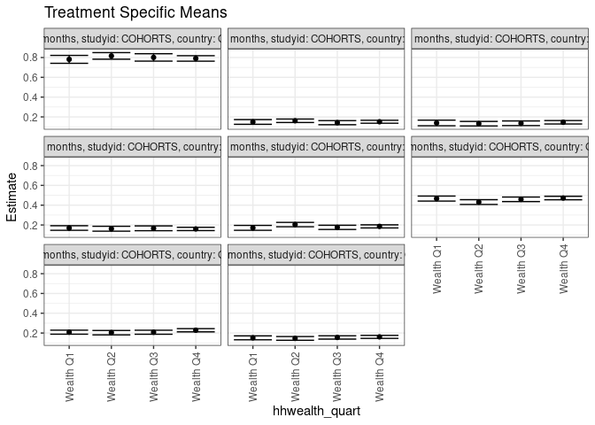

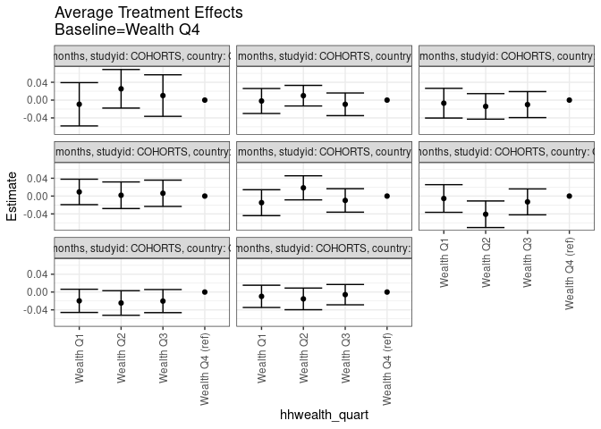

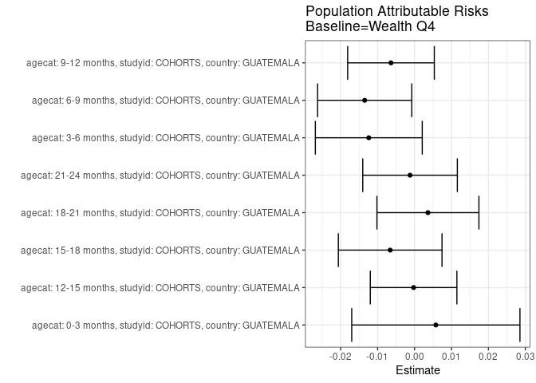

## Results Table

### Parameter: TSM

| agecat | studyid | country | intervention_level | baseline_level | estimate | ci_lower | ci_upper |
| --- | --- | --- | --- | --- | --- | --- | --- |
| 0-3 months | COHORTS | GUATEMALA | Wealth Q4 | NA | 0.7909881 | 0.7632773 | 0.8186988 |
| 0-3 months | COHORTS | GUATEMALA | Wealth Q1 | NA | 0.7816145 | 0.7416684 | 0.8215605 |
| 0-3 months | COHORTS | GUATEMALA | Wealth Q2 | NA | 0.8163249 | 0.7830895 | 0.8495603 |
| 0-3 months | COHORTS | GUATEMALA | Wealth Q3 | NA | 0.8011292 | 0.7636763 | 0.8385821 |
| 3-6 months | COHORTS | GUATEMALA | Wealth Q4 | NA | 0.4722456 | 0.4544578 | 0.4900334 |
| 3-6 months | COHORTS | GUATEMALA | Wealth Q1 | NA | 0.4668202 | 0.4414043 | 0.4922360 |
| 3-6 months | COHORTS | GUATEMALA | Wealth Q2 | NA | 0.4314303 | 0.4074838 | 0.4553769 |
| 3-6 months | COHORTS | GUATEMALA | Wealth Q3 | NA | 0.4592691 | 0.4362677 | 0.4822704 |
| 6-9 months | COHORTS | GUATEMALA | Wealth Q4 | NA | 0.2283146 | 0.2119816 | 0.2446475 |
| 6-9 months | COHORTS | GUATEMALA | Wealth Q1 | NA | 0.2085409 | 0.1882706 | 0.2288112 |
| 6-9 months | COHORTS | GUATEMALA | Wealth Q2 | NA | 0.2037690 | 0.1815585 | 0.2259794 |
| 6-9 months | COHORTS | GUATEMALA | Wealth Q3 | NA | 0.2080260 | 0.1879015 | 0.2281505 |
| 9-12 months | COHORTS | GUATEMALA | Wealth Q4 | NA | 0.1612384 | 0.1459100 | 0.1765668 |
| 9-12 months | COHORTS | GUATEMALA | Wealth Q1 | NA | 0.1515479 | 0.1318317 | 0.1712641 |
| 9-12 months | COHORTS | GUATEMALA | Wealth Q2 | NA | 0.1458731 | 0.1270493 | 0.1646968 |
| 9-12 months | COHORTS | GUATEMALA | Wealth Q3 | NA | 0.1554350 | 0.1385489 | 0.1723210 |
| 12-15 months | COHORTS | GUATEMALA | Wealth Q4 | NA | 0.1509624 | 0.1361818 | 0.1657429 |
| 12-15 months | COHORTS | GUATEMALA | Wealth Q1 | NA | 0.1489621 | 0.1251467 | 0.1727775 |
| 12-15 months | COHORTS | GUATEMALA | Wealth Q2 | NA | 0.1608988 | 0.1431544 | 0.1786433 |
| 12-15 months | COHORTS | GUATEMALA | Wealth Q3 | NA | 0.1415149 | 0.1208093 | 0.1622205 |
| 15-18 months | COHORTS | GUATEMALA | Wealth Q4 | NA | 0.1456383 | 0.1282542 | 0.1630223 |
| 15-18 months | COHORTS | GUATEMALA | Wealth Q1 | NA | 0.1387027 | 0.1103089 | 0.1670965 |
| 15-18 months | COHORTS | GUATEMALA | Wealth Q2 | NA | 0.1315226 | 0.1087740 | 0.1542713 |
| 15-18 months | COHORTS | GUATEMALA | Wealth Q3 | NA | 0.1355351 | 0.1120674 | 0.1590029 |
| 18-21 months | COHORTS | GUATEMALA | Wealth Q4 | NA | 0.1599652 | 0.1432135 | 0.1767169 |
| 18-21 months | COHORTS | GUATEMALA | Wealth Q1 | NA | 0.1692668 | 0.1460987 | 0.1924349 |
| 18-21 months | COHORTS | GUATEMALA | Wealth Q2 | NA | 0.1618068 | 0.1371052 | 0.1865083 |
| 18-21 months | COHORTS | GUATEMALA | Wealth Q3 | NA | 0.1662549 | 0.1419945 | 0.1905153 |
| 21-24 months | COHORTS | GUATEMALA | Wealth Q4 | NA | 0.1856923 | 0.1701489 | 0.2012356 |
| 21-24 months | COHORTS | GUATEMALA | Wealth Q1 | NA | 0.1708904 | 0.1463068 | 0.1954741 |
| 21-24 months | COHORTS | GUATEMALA | Wealth Q2 | NA | 0.2041690 | 0.1820723 | 0.2262656 |
| 21-24 months | COHORTS | GUATEMALA | Wealth Q3 | NA | 0.1758902 | 0.1546496 | 0.1971309 |

### Parameter: E(Y)

| agecat | studyid | country | intervention_level | baseline_level | estimate | ci_lower | ci_upper |
| --- | --- | --- | --- | --- | --- | --- | --- |
| 0-3 months | COHORTS | GUATEMALA | NA | NA | 0.7967509 | 0.7797129 | 0.8137889 |
| 3-6 months | COHORTS | GUATEMALA | NA | NA | 0.4598586 | 0.4488398 | 0.4708774 |
| 6-9 months | COHORTS | GUATEMALA | NA | NA | 0.2148174 | 0.2050742 | 0.2245606 |
| 9-12 months | COHORTS | GUATEMALA | NA | NA | 0.1548601 | 0.1460722 | 0.1636480 |
| 12-15 months | COHORTS | GUATEMALA | NA | NA | 0.1507021 | 0.1414031 | 0.1600010 |
| 15-18 months | COHORTS | GUATEMALA | NA | NA | 0.1390423 | 0.1279954 | 0.1500893 |
| 18-21 months | COHORTS | GUATEMALA | NA | NA | 0.1635896 | 0.1528248 | 0.1743543 |
| 21-24 months | COHORTS | GUATEMALA | NA | NA | 0.1844754 | 0.1744220 | 0.1945287 |

### Parameter: ATE

| agecat | studyid | country | intervention_level | baseline_level | estimate | ci_lower | ci_upper |
| --- | --- | --- | --- | --- | --- | --- | --- |
| 0-3 months | COHORTS | GUATEMALA | Wealth Q4 | Wealth Q4 | 0.0000000 | 0.0000000 | 0.0000000 |
| 0-3 months | COHORTS | GUATEMALA | Wealth Q1 | Wealth Q4 | -0.0093736 | -0.0579902 | 0.0392430 |
| 0-3 months | COHORTS | GUATEMALA | Wealth Q2 | Wealth Q4 | 0.0253368 | -0.0179353 | 0.0686089 |
| 0-3 months | COHORTS | GUATEMALA | Wealth Q3 | Wealth Q4 | 0.0101411 | -0.0364487 | 0.0567309 |
| 3-6 months | COHORTS | GUATEMALA | Wealth Q4 | Wealth Q4 | 0.0000000 | 0.0000000 | 0.0000000 |
| 3-6 months | COHORTS | GUATEMALA | Wealth Q1 | Wealth Q4 | -0.0054254 | -0.0364476 | 0.0255967 |
| 3-6 months | COHORTS | GUATEMALA | Wealth Q2 | Wealth Q4 | -0.0408152 | -0.0706455 | -0.0109850 |
| 3-6 months | COHORTS | GUATEMALA | Wealth Q3 | Wealth Q4 | -0.0129765 | -0.0420534 | 0.0161004 |
| 6-9 months | COHORTS | GUATEMALA | Wealth Q4 | Wealth Q4 | 0.0000000 | 0.0000000 | 0.0000000 |
| 6-9 months | COHORTS | GUATEMALA | Wealth Q1 | Wealth Q4 | -0.0197737 | -0.0458054 | 0.0062581 |
| 6-9 months | COHORTS | GUATEMALA | Wealth Q2 | Wealth Q4 | -0.0245456 | -0.0521150 | 0.0030238 |
| 6-9 months | COHORTS | GUATEMALA | Wealth Q3 | Wealth Q4 | -0.0202886 | -0.0462069 | 0.0056298 |
| 9-12 months | COHORTS | GUATEMALA | Wealth Q4 | Wealth Q4 | 0.0000000 | 0.0000000 | 0.0000000 |
| 9-12 months | COHORTS | GUATEMALA | Wealth Q1 | Wealth Q4 | -0.0096905 | -0.0346643 | 0.0152832 |
| 9-12 months | COHORTS | GUATEMALA | Wealth Q2 | Wealth Q4 | -0.0153654 | -0.0396407 | 0.0089100 |
| 9-12 months | COHORTS | GUATEMALA | Wealth Q3 | Wealth Q4 | -0.0058035 | -0.0286091 | 0.0170022 |
| 12-15 months | COHORTS | GUATEMALA | Wealth Q4 | Wealth Q4 | 0.0000000 | 0.0000000 | 0.0000000 |
| 12-15 months | COHORTS | GUATEMALA | Wealth Q1 | Wealth Q4 | -0.0020003 | -0.0300295 | 0.0260290 |
| 12-15 months | COHORTS | GUATEMALA | Wealth Q2 | Wealth Q4 | 0.0099365 | -0.0131575 | 0.0330304 |
| 12-15 months | COHORTS | GUATEMALA | Wealth Q3 | Wealth Q4 | -0.0094475 | -0.0348873 | 0.0159924 |
| 15-18 months | COHORTS | GUATEMALA | Wealth Q4 | Wealth Q4 | 0.0000000 | 0.0000000 | 0.0000000 |
| 15-18 months | COHORTS | GUATEMALA | Wealth Q1 | Wealth Q4 | -0.0069356 | -0.0402284 | 0.0263573 |
| 15-18 months | COHORTS | GUATEMALA | Wealth Q2 | Wealth Q4 | -0.0141156 | -0.0427462 | 0.0145149 |
| 15-18 months | COHORTS | GUATEMALA | Wealth Q3 | Wealth Q4 | -0.0101031 | -0.0393082 | 0.0191020 |
| 18-21 months | COHORTS | GUATEMALA | Wealth Q4 | Wealth Q4 | 0.0000000 | 0.0000000 | 0.0000000 |
| 18-21 months | COHORTS | GUATEMALA | Wealth Q1 | Wealth Q4 | 0.0093016 | -0.0192882 | 0.0378915 |
| 18-21 months | COHORTS | GUATEMALA | Wealth Q2 | Wealth Q4 | 0.0018415 | -0.0280045 | 0.0316876 |
| 18-21 months | COHORTS | GUATEMALA | Wealth Q3 | Wealth Q4 | 0.0062897 | -0.0231923 | 0.0357716 |
| 21-24 months | COHORTS | GUATEMALA | Wealth Q4 | Wealth Q4 | 0.0000000 | 0.0000000 | 0.0000000 |
| 21-24 months | COHORTS | GUATEMALA | Wealth Q1 | Wealth Q4 | -0.0148018 | -0.0438870 | 0.0142834 |
| 21-24 months | COHORTS | GUATEMALA | Wealth Q2 | Wealth Q4 | 0.0184767 | -0.0085391 | 0.0454926 |
| 21-24 months | COHORTS | GUATEMALA | Wealth Q3 | Wealth Q4 | -0.0098020 | -0.0361224 | 0.0165183 |

### Parameter: PAR

| agecat | studyid | country | intervention_level | baseline_level | estimate | ci_lower | ci_upper |
| --- | --- | --- | --- | --- | --- | --- | --- |
| 0-3 months | COHORTS | GUATEMALA | Wealth Q4 | NA | 0.0057628 | -0.0170073 | 0.0285329 |
| 3-6 months | COHORTS | GUATEMALA | Wealth Q4 | NA | -0.0123870 | -0.0268575 | 0.0020835 |
| 6-9 months | COHORTS | GUATEMALA | Wealth Q4 | NA | -0.0134971 | -0.0262461 | -0.0007481 |
| 9-12 months | COHORTS | GUATEMALA | Wealth Q4 | NA | -0.0063783 | -0.0181087 | 0.0053520 |
| 12-15 months | COHORTS | GUATEMALA | Wealth Q4 | NA | -0.0002603 | -0.0119851 | 0.0114645 |
| 15-18 months | COHORTS | GUATEMALA | Wealth Q4 | NA | -0.0065959 | -0.0206318 | 0.0074400 |
| 18-21 months | COHORTS | GUATEMALA | Wealth Q4 | NA | 0.0036244 | -0.0101785 | 0.0174272 |
| 21-24 months | COHORTS | GUATEMALA | Wealth Q4 | NA | -0.0012169 | -0.0140206 | 0.0115868 |